# Actividad 4

Jonathan David Castillo

2026-09-03

*Preview*: Library’s

**#Data Quality Analysis**

- *Step 1*: We retrieved information on *Cavendishia pubescens*, a species of economic and ecological importance.Fig 1. reproductive structurs the *C. pubescens*

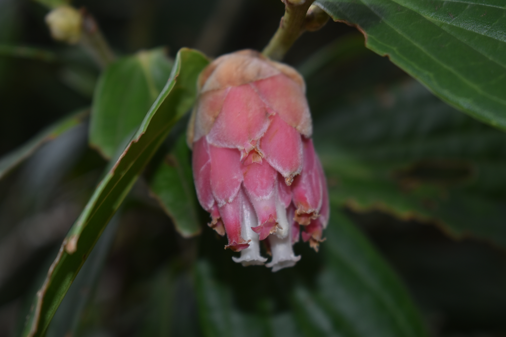

- *Step 2*: Convert GBIF information into a table to analyze the overall content

```r
dados = Cp_GBIF$data
```

- *Step 3*:Inspect the data to identify possible table formatting errors

```r
dim(Cp_GBIF)
```

[output not shown]

```r
names(Cp_GBIF)
```

```
## [1] "meta"            "hierarchy"       "data"            "media"
## [5] "classifications" "facets"
```

```r
str(dados)
```

```
## tibble [1,352 × 201] (S3: tbl_df/tbl/data.frame)
##  $ key                                        : chr [1:1352] "6162808808" "6413688098" "6184904661" "6456523582" ...
##  $ scientificName                             : chr [1:1352] "Cavendishia pubescens (Kunth) Hemsl." "Cavendishia pubescens (Kunth) Hemsl." "Cavendishia pubescens (Kunth) Hemsl." "Cavendishia pubescens (Kunth) Hemsl." ...
##  $ decimalLatitude                            : num [1:1352] 1.72 5.95 6.04 5.36 5.4 ...
##  $ decimalLongitude                           : num [1:1352] -76.1 -75.6 -75.6 -74.4 -74.2 ...
##  $ issues                                     : chr [1:1352] "cdc,cdround" "cdc,cdround" "cdc,cdround" "cdround" ...
##  $ datasetKey                                 : chr [1:1352] "50c9509d-22c7-4a22-a47d-8c48425ef4a7" "50c9509d-22c7-4a22-a47d-8c48425ef4a7" "50c9509d-22c7-4a22-a47d-8c48425ef4a7" "b5267992-4ec9-4dc4-ae9b-8a3698661022" ...
##  $ publishingOrgKey                           : chr [1:1352] "28eb1a3f-1c15-4a95-931a-4af90ecb574d" "28eb1a3f-1c15-4a95-931a-4af90ecb574d" "28eb1a3f-1c15-4a95-931a-4af90ecb574d" "47380c8a-0edd-4036-b1bc-d852cba8232f" ...
##  $ X.CitizenScience.                          : chr [1:1352] "CitizenScience" "CitizenScience" "CitizenScience" NA ...
##  $ installationKey                            : chr [1:1352] "997448a8-f762-11e1-a439-00145eb45e9a" "997448a8-f762-11e1-a439-00145eb45e9a" "997448a8-f762-11e1-a439-00145eb45e9a" "68845aab-a453-4816-b36d-a3ec8455deb0" ...
##  $ hostingOrganizationKey                     : chr [1:1352] "28eb1a3f-1c15-4a95-931a-4af90ecb574d" "28eb1a3f-1c15-4a95-931a-4af90ecb574d" "28eb1a3f-1c15-4a95-931a-4af90ecb574d" "c4f66525-4d36-4c18-82ac-98e088f54db4" ...
##  $ publishingCountry                          : chr [1:1352] "US" "US" "US" "CO" ...
##  $ protocol                                   : chr [1:1352] "DWC_ARCHIVE" "DWC_ARCHIVE" "DWC_ARCHIVE" "EML" ...
##  $ lastCrawled                                : chr [1:1352] "2026-08-28T18:34:26.589+00:00" "2026-08-28T18:34:26.589+00:00" "2026-08-28T18:34:26.589+00:00" "2026-08-03T16:03:35.832+00:00" ...
##  $ lastParsed                                 : chr [1:1352] "2026-09-02T08:35:44.278+00:00" "2026-09-02T09:06:42.572+00:00" "2026-09-02T09:04:58.118+00:00" "2026-08-03T16:03:50.456+00:00" ...
```

[output cut: 86 more lines]

- *Step 4*: Verify the species taxonomy to avoid possible errors when downloading the information

```r
unique(dados$scientificName)
```

```
## [1] "Cavendishia pubescens (Kunth) Hemsl."
## [2] "Cavendishia pubescens var. boliviensis Hoerold"
## [3] "Thibaudia pubescens Kunth"
## [4] "Thibaudia septemnervia Willd. ex Walp."
## [5] "Thibaudia cinnamomifolia Willd. ex Walp."
```

*Note*:In the taxonomic information for *Cavendishia pubescens*, it should be associated with the Ericaceae family and the Ericales order

```r
dados %>%
  distinct(
    kingdom,
    phylum,
    class,
    order,
    family,
    genus,
    species)
```

```
## # A tibble: 1 × 7
##   kingdom phylum       class         order    family    genus       species
##   <chr>   <chr>        <chr>         <chr>    <chr>     <chr>       <chr>
## 1 Plantae Tracheophyta Magnoliopsida Ericales Ericaceae Cavendishia Cavendishia…
```

- *Step 5*: We reviewed the “issues” column to identify errors detected by GBIF and classified those that represented data noise.

```r
dados$issues
```

```
##    [1] "cdc,cdround"
##    [2] "cdc,cdround"
##    [3] "cdc,cdround"
##    [4] "cdround"
##    [5] "cdround"
##    [6] "cdc,cdround"
##    [7] "cdc,cdround"
##    [8] "cdc,cdround"
##    [9] "cdc,cdround"
##   [10] "cdc,cdround"
##   [11] "cdc,cdround"
##   [12] "cdc,cdround"
##   [13] "cdc"
##   [14] "cdc,cdround"
##   [15] "cdc,cdround"
```

[output cut: 1337 more lines]

- *Step 6*: Detect specific errors “issues” and we performed the filtering

```r
issues_gbif <- dados$issues %>%
  unique() %>%
  strsplit(., "[,]") %>%
  unlist()
```

- *Step 7*: Show the filtering

```r
issues_gbif
```

```
##   [1] "cdc"       "cdround"   "cdround"   "cdc"       "cdround"   "gass84"
##   [7] "osiic"     "colmano"   "inmafu"    "colmafu"   "inmafu"    "cdround"
##  [13] "colmano"   "inmafu"    "cdround"   "colmafu"   "inmafu"    "cdround"
##  [19] "inmafu"    "cdround"   "elmms"     "inmafu"    "cdc"       "cdround"
##  [25] "colmafu"   "inmafu"    "cdc"       "cdround"   "gass84"    "osiic"
##  [31] "inmafu"    "cdround"   "gass84"    "inmafu"    "cdc"       "muluriiv"
##  [37] "gass84"    "osiic"     "cdc"       "cdround"   "gass84"    "colmafu"
##  [43] "inmafu"    "cdc"       "inmafu"    "gass84"    "mdativ"    "gass84"
##  [49] "cdround"   "gass84"    "osiic"     "inmano"    "ambinst"   "cdround"
##  [55] "rdatm"     "inmafu"    "inmafu"    "gass84"    "osiic"     "inmano"
##  [61] "cdround"   "gass84"    "osiic"     "ambinst"   "gass84"    "osiic"
##  [67] "ambinst"   "gass84"    "osiic"     "colmano"   "inmafu"    "cdc"
##  [73] "gass84"    "inmafu"    "gass84"    "ambcol"    "inmafu"    "cdc"
##  [79] "cdround"   "inmafu"    "cdround"   "gass84"    "mdativ"    "mdativ"
##  [85] "cdround"   "gass84"    "cdround"   "gass84"    "colmafu"   "inmafu"
```

[output cut: 23 more lines]

- *Step 8*: Show the issues that appear exclusively in my data -issues percentajes-

```r
dados %>%
  summarise(
    total = n(),
    com_issue = sum(!is.na(issues) & issues != ""),
    sem_issue = sum(is.na(issues) | issues == ""),
    porcentagem_com_issue = 100 * com_issue / total
  )
```

```
## # A tibble: 1 × 4
##   total com_issue sem_issue porcentagem_com_issue
##   <int>     <int>     <int>                 <dbl>
## 1  1352       973       379                  72.0
```

*Note*: Show the issues

```r
dados %>%
  filter(!is.na(issues) & issues != "")
```

```
## # A tibble: 973 × 201
##    key        scientificName  decimalLatitude decimalLongitude issues datasetKey
##    <chr>      <chr>                     <dbl>            <dbl> <chr>  <chr>
##  1 6162808808 Cavendishia pu…            1.72            -76.1 cdc,c… 50c9509d-…
##  2 6413688098 Cavendishia pu…            5.95            -75.6 cdc,c… 50c9509d-…
##  3 6184904661 Cavendishia pu…            6.04            -75.6 cdc,c… 50c9509d-…
##  4 6456523582 Cavendishia pu…            5.36            -74.4 cdrou… b5267992-…
##  5 6456523700 Cavendishia pu…            5.40            -74.2 cdrou… b5267992-…
##  6 6251752339 Cavendishia pu…            6.35            -75.7 cdc,c… 50c9509d-…
##  7 6251872973 Cavendishia pu…            6.25            -75.6 cdc,c… 50c9509d-…
##  8 6253081304 Cavendishia pu…            6.22            -75.5 cdc,c… 50c9509d-…
##  9 6253116564 Cavendishia pu…            6.24            -75.7 cdc,c… 50c9509d-…
## 10 6320335816 Cavendishia pu…            6.19            -75.7 cdc,c… 50c9509d-…
## # ℹ 963 more rows
## # ℹ 195 more variables: publishingOrgKey <chr>, X.CitizenScience. <chr>,
## #   installationKey <chr>, hostingOrganizationKey <chr>,
## #   publishingCountry <chr>, protocol <chr>, lastCrawled <chr>,
## #   lastParsed <chr>, crawlId <int>, basisOfRecord <chr>,
## #   occurrenceStatus <chr>, taxonKey <int>, kingdomKey <int>, phylumKey <int>,
## #   classKey <int>, orderKey <int>, familyKey <int>, genusKey <int>, …
```

##Cleaning the general matrix

- *Step 9*: We select only columns that will be used

```r
dados1 <- dados %>%
  select(
    gbifID,
    scientificName,
    acceptedScientificName,
    decimalLatitude,
    decimalLongitude,
    geodeticDatum,
    issues,
    continent,
    country,
    countryCode,
    stateProvince,
    county,
    municipality,
    locality,
    basisOfRecord,
    occurrenceStatus,
    taxonomicStatus,
    datasetName,
    datasetKey,
    publishingOrgKey,
    institutionCode,
    collectionCode,
    recordedBy,
    identifiedBy,
    eventDate,
    year,
    month,
    day,
    habitat,
    elevation,
    elevationAccuracy,
    occurrenceRemarks,
    license,
    rightsHolder)
```

- *Step 10*: Remove duplicate records

```r
dados1 <- dados1 %>%
  distinct()
```

- *Step 11*: Check the unique values

```r
lapply(dados1, function(x) {
  head(unique(x), 20)
})
```

```
## $gbifID
##  [1] "6162808808" "6413688098" "6184904661" "6456523582" "6456523700"
##  [6] "6251752339" "6251872973" "6253081304" "6253116564" "6320335816"
## [11] "6320336733" "6441368536" "6451894953" "5087882189" "5140931773"
## [16] "5153674483" "5153902338" "5154471421" "5292605846" "6217134486"
##
## $scientificName
## [1] "Cavendishia pubescens (Kunth) Hemsl."
## [2] "Cavendishia pubescens var. boliviensis Hoerold"
## [3] "Thibaudia pubescens Kunth"
## [4] "Thibaudia septemnervia Willd. ex Walp."
## [5] "Thibaudia cinnamomifolia Willd. ex Walp."
##
## $acceptedScientificName
## [1] "Cavendishia pubescens (Kunth) Hemsl."
```

[output cut: 325 more lines]

```r
dados1 <- dados1 %>%
  filter(
    !is.na(decimalLatitude),
    !is.na(decimalLongitude)
  )
```

- *Step 13*: Identify other coordinate-related issues and remove them

```r
cl <- CoordinateCleaner::clean_coordinates(
  dados1,
  species = "acceptedScientificName",
  lat = "decimalLatitude",
  lon = "decimalLongitude",
  tests = c(
    "capitals",
    "centroids",
    "equal",
    "gbif",
    "institutions",
    "outliers",
    "seas",
    "zeros"
  )
)
```

```
## Testing coordinate validity
```

```
## Flagged 0 records.
```

```
## Testing equal lat/lon
```

```
## Flagged 3 records.
```

```
## Testing zero coordinates
```

```
## Flagged 3 records.
```

```
## Testing country capitals
```

```
## Flagged 1 records.
```

```
## Testing country centroids
```

```
## Flagged 3 records.
```

```
## Testing sea coordinates
```

```
## Reading 'ne_50m_land.zip' from naturalearth...
## Flagged 4 records.
##
## Testing geographic outliers
##
## Flagged 3 records.
##
## Testing GBIF headquarters, flagging records around Copenhagen
##
## Flagged 0 records.
##
## Testing biodiversity institutions
##
## Flagged 0 records.
##
## Flagged 5 of 888 records, EQ = 0.01.
```

- *Step 14*:Verify the information generated by the “CoordinateCleaner” command

```r
cl %>%
  select(
    decimalLatitude,
    decimalLongitude,
    starts_with(".")
  )
```

```
##     decimalLatitude decimalLongitude .val  .equ  .zer  .cap  .cen  .sea  .otl
## 1          1.720689        -76.11890 TRUE  TRUE  TRUE  TRUE  TRUE  TRUE  TRUE
## 2          5.953463        -75.64044 TRUE  TRUE  TRUE  TRUE  TRUE  TRUE  TRUE
## 3          6.038020        -75.61733 TRUE  TRUE  TRUE  TRUE  TRUE  TRUE  TRUE
## 4          5.363242        -74.43750 TRUE  TRUE  TRUE  TRUE  TRUE  TRUE  TRUE
## 5          5.395569        -74.20206 TRUE  TRUE  TRUE  TRUE  TRUE  TRUE  TRUE
## 6          6.346460        -75.67409 TRUE  TRUE  TRUE  TRUE  TRUE  TRUE  TRUE
## 7          6.251470        -75.64755 TRUE  TRUE  TRUE  TRUE  TRUE  TRUE  TRUE
## 8          6.218238        -75.49898 TRUE  TRUE  TRUE  TRUE  TRUE  TRUE  TRUE
## 9          6.235781        -75.65015 TRUE  TRUE  TRUE  TRUE  TRUE  TRUE  TRUE
## 10         6.192020        -75.66821 TRUE  TRUE  TRUE  TRUE  TRUE  TRUE  TRUE
## 11         6.070783        -75.33399 TRUE  TRUE  TRUE  TRUE  TRUE  TRUE  TRUE
## 12         6.405272        -75.98355 TRUE  TRUE  TRUE  TRUE  TRUE  TRUE  TRUE
## 13         5.769028        -75.24581 TRUE  TRUE  TRUE  TRUE  TRUE  TRUE  TRUE
## 14         6.234159        -75.17490 TRUE  TRUE  TRUE  TRUE  TRUE  TRUE  TRUE
```

[output cut: 1763 more lines]

- *Step 15*:Check the number of usable records

```r
cl %>%
  summarise(
    validos = sum(.summary == TRUE),
    sospechosos = sum(.summary == FALSE),
    total = n()
  )
```

```
##   validos sospechosos total
## 1     883           5   888
```

##Matrix with cleaned and filtered coordinates

- *Step 16*:Generate the new matrix

```r
dados_clean <- dados1 %>%
  filter(cl$.summary == TRUE)
```

- *Step 17*: Verification of the new coordinates

```r
dados_clean %>%
  summarise(
    total = n(),
    lat_NA = sum(is.na(decimalLatitude)),
    lon_NA = sum(is.na(decimalLongitude)),
    lat_min = min(decimalLatitude),
    lat_max = max(decimalLatitude),
    lon_min = min(decimalLongitude),
    lon_max = max(decimalLongitude)
  )
```

```
## # A tibble: 1 × 7
##   total lat_NA lon_NA lat_min lat_max lon_min lon_max
##   <int>  <int>  <int>   <dbl>   <dbl>   <dbl>   <dbl>
## 1   883      0      0   -17.1    10.4   -82.7   -59.9
```

###Generate maps

- *Step 18*:Generate map with raw data

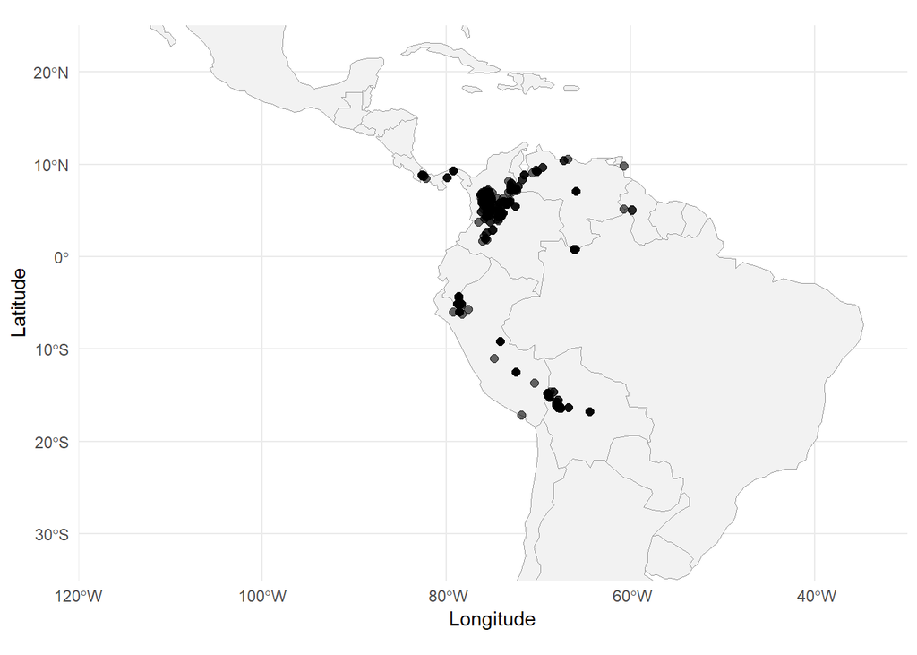

```r
library(rnaturalearth)
library(sf)
library(ggplot2)

paises <- ne_countries(
  returnclass = "sf"
)

ggplot() +
  geom_sf(
    data = paises,
    fill = "gray95",
    color = "gray60",
    linewidth = 0.3
  ) +
  geom_point(
    data = dados1,
    aes(
      x = decimalLongitude,
      y = decimalLatitude
    ),
    size = 2,
    alpha = 0.6
  ) +
  coord_sf(
    xlim = c(-120, -30),
    ylim = c(-35, 25),
    expand = FALSE
  ) +
  labs(
    x = "Longitude",
    y = "Latitude"
  ) +
  theme_minimal()
```

- *Step 19*: Show records located in the ocean, since *Cavendishia pubescens* is a terrestrial plant species with a relatively limited distribution.

```r
registros_mar <- dados1[cl$.sea == FALSE, ]

registros_mar %>%
  select(
    gbifID,
    scientificName,
    decimalLatitude,
    decimalLongitude,
    country,
    stateProvince,
    municipality,
    locality,
    datasetName,
    basisOfRecord,
    institutionCode,
    recordedBy,
    eventDate,
    issues)
```

```
## # A tibble: 4 × 14
##   gbifID   scientificName decimalLatitude decimalLongitude country stateProvince
##   <chr>    <chr>                    <dbl>            <dbl> <chr>   <chr>
## 1 2996578… Cavendishia p…             0                0   Colomb… <NA>
## 2 2996740… Cavendishia p…             0                0   Bolivi… <NA>
## 3 2996562… Cavendishia p…             0                0   Bolivi… <NA>
## 4 1928431… Cavendishia p…             9.8            -60.8 Venezu… Lara
## # ℹ 8 more variables: municipality <chr>, locality <chr>, datasetName <chr>,
## #   basisOfRecord <chr>, institutionCode <chr>, recordedBy <chr>,
## #   eventDate <chr>, issues <chr>
```

- *Step 20*: Removed records located in the ocean

```r
dados_clean <- dados1 %>%
  filter(cl$.sea == TRUE)
```

- *Step 21*: Occurrences differentiated by country

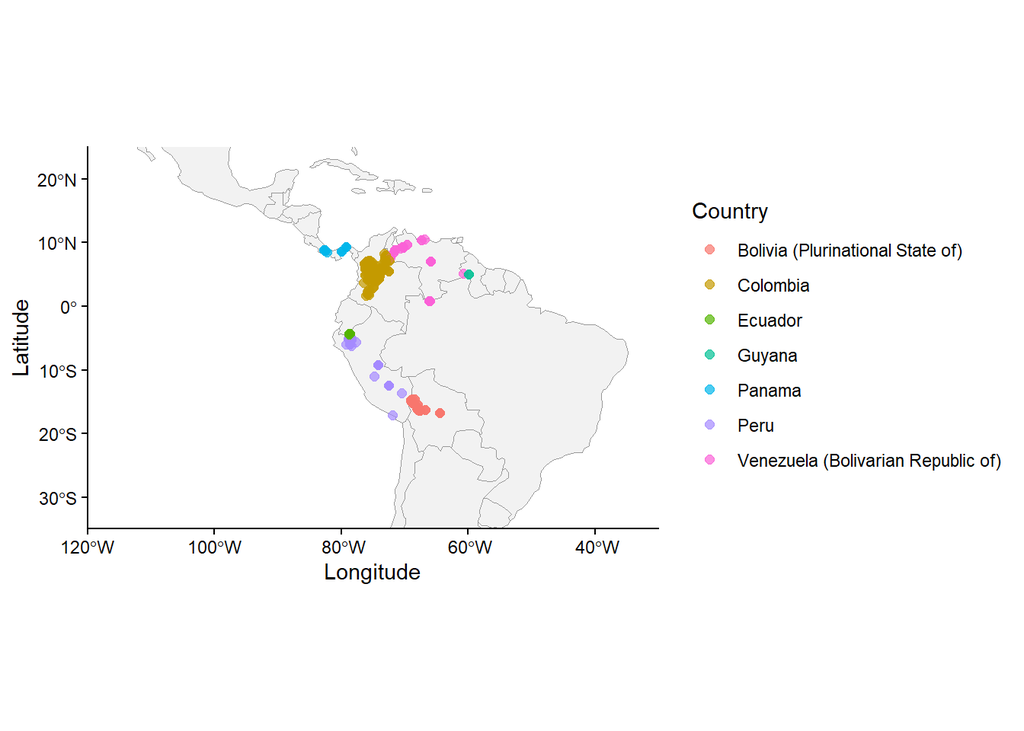

##Final dataset